# Week 12 : Breast cancer analysis: Machine Learning to Predict whether the cancer is benign or malignant.

Mohammed Majjaj

11/18/2020

## **Problem Statement**

Worldwide, Breast cancer is one of the most common cancers that attacks women, it takes the lion share of new cancer cases and cancer-related deaths according to global statistics, making it a significant public health problem in today’s society. Early diagnosis can improve the chance of survival significantly, and it can promote timely clinical treatments to patients. Using Breast Cancer Wisconsin (Diagnostic) Data Set, I will try to apply statistical knowledge I accumulated during this course to build a machine learning model to predict whether a cancer is benign or malignant with a high accuracy.

## **Research questions**

1. Identify the variables used in this study, is there any data cleaning or variable modification needed?
2. Explore the dataset for a quick exploratory analysis. central tendency and measures of dispersion?
3. Do we have outliers, and what should be done with them?
4. What are the best statistical methods to correlate this data?
5. What are the variables that correlate the most with the outcome with significance?
6. What are the variables that explains most of the variability of the outcome with significance?
7. What machine learning models to choose from to best predict the outcome?
8. Which model best predict the outcome based on accuracy?

#### **Overview of the Data Set**

The dataset I will use (Diagnostic Wisconsin Breast Cancer Database) is a CSV file. the Features are computed from a digitized image of a fine needle aspirate (FNA) of a breast mass. They describe characteristics of the cell nuclei present in the image.

##### **Dataset information:**

• Dataset Characteristics: Multivariate • Attribute Characteristics: Real • Attribute Characteristics: Classification • Number of Instances: 569 • Number of Attributes: 32 • Missing Values: No

##### **Attribute Information:**

1. ID number
2. Diagnosis (M = malignant, B = benign) 3-32)

Ten real-valued features are computed for each cell nucleus:

1. radius (mean of distances from center to points on the perimeter)
2. texture (standard deviation of gray-scale values)
3. perimeter
4. area
5. smoothness (local variation in radius lengths)
6. compactness (perimeter^2 / area - 1.0)
7. concavity (severity of concave portions of the contour)
8. concave points (number of concave portions of the contour)
9. symmetry
10. fractal dimension (“coastline approximation” - 1)

The mean, standard error and “worst” or largest (mean of the three largest values) of these features were computed for each image, resulting in 30 features. For instance, field 3 is Mean Radius, field 13 is Radius SE, field 23 is Worst Radius.

This data set is available through Kaggle : https://www.kaggle.com/uciml/breast-cancer-wisconsin-data and is also available through the UW CS ftp server: ftp ftp.cs.wisc.edu cd math-prog/cpo-dataset/machine-learn/WDBC/

#### **Data importing and cleaning steps**

After I set my data directory will import the data set and do a preliminary investigation to see if it needs any cleaning done.

```r
# Load the `caTools` library
library(caTools)

# Load the `data.csv` as df
df <- read.csv("data.csv")

str(df)
```

```
## 'data.frame':    569 obs. of  33 variables:
##  $ id                     : int  842302 842517 84300903 84348301 84358402 843786 844359 84458202 844981 84501001 ...
##  $ diagnosis              : chr  "M" "M" "M" "M" ...
##  $ radius_mean            : num  18 20.6 19.7 11.4 20.3 ...
##  $ texture_mean           : num  10.4 17.8 21.2 20.4 14.3 ...
##  $ perimeter_mean         : num  122.8 132.9 130 77.6 135.1 ...
##  $ area_mean              : num  1001 1326 1203 386 1297 ...
##  $ smoothness_mean        : num  0.1184 0.0847 0.1096 0.1425 0.1003 ...
##  $ compactness_mean       : num  0.2776 0.0786 0.1599 0.2839 0.1328 ...
##  $ concavity_mean         : num  0.3001 0.0869 0.1974 0.2414 0.198 ...
##  $ concave.points_mean    : num  0.1471 0.0702 0.1279 0.1052 0.1043 ...
##  $ symmetry_mean          : num  0.242 0.181 0.207 0.26 0.181 ...
##  $ fractal_dimension_mean : num  0.0787 0.0567 0.06 0.0974 0.0588 ...
##  $ radius_se              : num  1.095 0.543 0.746 0.496 0.757 ...
##  $ texture_se             : num  0.905 0.734 0.787 1.156 0.781 ...
```

[output cut: 19 more lines]

The data set is 569 obs. Of 33 variables

First look I can see that I can remove the Id column.

I’ve checked if there is any duplicates using function any(duplicated(data))result was False.

Last column X has no data in it; checked using function summary(data$X) all rows are NA’s.

Diagnosis need to be converted to numeric factor.

will replace M = 0 and B = 1.

```r
#check for duplicates
any(duplicated(df$id))
```

```
## [1] FALSE
```

```r
#remove column id
data= subset(df, select = -c(id))

#check column X
summary(data$X)
```

```
##    Mode    NA's
## logical     569
```

```r
#remove column X
data= subset(data, select = -c(X))

#check for NA's
any(is.na(data))
```

```
## [1] FALSE
```

```r
data$diagnosis[data$diagnosis=='M'] = 0 # replace M=0
data$diagnosis[data$diagnosis=='B'] = 1 # replace B=1

#convert diagnisis into numeric
data$diagnosis= as.numeric(data$diagnosis)


str(data) #checking result
```

```
## 'data.frame':    569 obs. of  31 variables:
##  $ diagnosis              : num  0 0 0 0 0 0 0 0 0 0 ...
##  $ radius_mean            : num  18 20.6 19.7 11.4 20.3 ...
##  $ texture_mean           : num  10.4 17.8 21.2 20.4 14.3 ...
##  $ perimeter_mean         : num  122.8 132.9 130 77.6 135.1 ...
##  $ area_mean              : num  1001 1326 1203 386 1297 ...
##  $ smoothness_mean        : num  0.1184 0.0847 0.1096 0.1425 0.1003 ...
##  $ compactness_mean       : num  0.2776 0.0786 0.1599 0.2839 0.1328 ...
##  $ concavity_mean         : num  0.3001 0.0869 0.1974 0.2414 0.198 ...
##  $ concave.points_mean    : num  0.1471 0.0702 0.1279 0.1052 0.1043 ...
##  $ symmetry_mean          : num  0.242 0.181 0.207 0.26 0.181 ...
##  $ fractal_dimension_mean : num  0.0787 0.0567 0.06 0.0974 0.0588 ...
##  $ radius_se              : num  1.095 0.543 0.746 0.496 0.757 ...
##  $ texture_se             : num  0.905 0.734 0.787 1.156 0.781 ...
##  $ perimeter_se           : num  8.59 3.4 4.58 3.44 5.44 ...
```

[output cut: 17 more lines]

#### **what the data set looks like.**

Here is the data head and summary of the data, which gives different statistic of the variables

```r
 summary(data) # this will describe the all statistical function of our data
```

```
##    diagnosis       radius_mean      texture_mean   perimeter_mean
##  Min.   :0.0000   Min.   : 6.981   Min.   : 9.71   Min.   : 43.79
##  1st Qu.:0.0000   1st Qu.:11.700   1st Qu.:16.17   1st Qu.: 75.17
##  Median :1.0000   Median :13.370   Median :18.84   Median : 86.24
##  Mean   :0.6274   Mean   :14.127   Mean   :19.29   Mean   : 91.97
##  3rd Qu.:1.0000   3rd Qu.:15.780   3rd Qu.:21.80   3rd Qu.:104.10
##  Max.   :1.0000   Max.   :28.110   Max.   :39.28   Max.   :188.50
##    area_mean      smoothness_mean   compactness_mean  concavity_mean
##  Min.   : 143.5   Min.   :0.05263   Min.   :0.01938   Min.   :0.00000
##  1st Qu.: 420.3   1st Qu.:0.08637   1st Qu.:0.06492   1st Qu.:0.02956
##  Median : 551.1   Median :0.09587   Median :0.09263   Median :0.06154
##  Mean   : 654.9   Mean   :0.09636   Mean   :0.10434   Mean   :0.08880
##  3rd Qu.: 782.7   3rd Qu.:0.10530   3rd Qu.:0.13040   3rd Qu.:0.13070
##  Max.   :2501.0   Max.   :0.16340   Max.   :0.34540   Max.   :0.42680
##  concave.points_mean symmetry_mean    fractal_dimension_mean   radius_se
##  Min.   :0.00000     Min.   :0.1060   Min.   :0.04996        Min.   :0.1115
##  1st Qu.:0.02031     1st Qu.:0.1619   1st Qu.:0.05770        1st Qu.:0.2324
##  Median :0.03350     Median :0.1792   Median :0.06154        Median :0.3242
##  Mean   :0.04892     Mean   :0.1812   Mean   :0.06280        Mean   :0.4052
##  3rd Qu.:0.07400     3rd Qu.:0.1957   3rd Qu.:0.06612        3rd Qu.:0.4789
##  Max.   :0.20120     Max.   :0.3040   Max.   :0.09744        Max.   :2.8730
##    texture_se      perimeter_se       area_se        smoothness_se
##  Min.   :0.3602   Min.   : 0.757   Min.   :  6.802   Min.   :0.001713
##  1st Qu.:0.8339   1st Qu.: 1.606   1st Qu.: 17.850   1st Qu.:0.005169
##  Median :1.1080   Median : 2.287   Median : 24.530   Median :0.006380
##  Mean   :1.2169   Mean   : 2.866   Mean   : 40.337   Mean   :0.007041
##  3rd Qu.:1.4740   3rd Qu.: 3.357   3rd Qu.: 45.190   3rd Qu.:0.008146
##  Max.   :4.8850   Max.   :21.980   Max.   :542.200   Max.   :0.031130
##  compactness_se      concavity_se     concave.points_se   symmetry_se
##  Min.   :0.002252   Min.   :0.00000   Min.   :0.000000   Min.   :0.007882
##  1st Qu.:0.013080   1st Qu.:0.01509   1st Qu.:0.007638   1st Qu.:0.015160
##  Median :0.020450   Median :0.02589   Median :0.010930   Median :0.018730
##  Mean   :0.025478   Mean   :0.03189   Mean   :0.011796   Mean   :0.020542
##  3rd Qu.:0.032450   3rd Qu.:0.04205   3rd Qu.:0.014710   3rd Qu.:0.023480
##  Max.   :0.135400   Max.   :0.39600   Max.   :0.052790   Max.   :0.078950
##  fractal_dimension_se  radius_worst   texture_worst   perimeter_worst
##  Min.   :0.0008948    Min.   : 7.93   Min.   :12.02   Min.   : 50.41
##  1st Qu.:0.0022480    1st Qu.:13.01   1st Qu.:21.08   1st Qu.: 84.11
##  Median :0.0031870    Median :14.97   Median :25.41   Median : 97.66
##  Mean   :0.0037949    Mean   :16.27   Mean   :25.68   Mean   :107.26
##  3rd Qu.:0.0045580    3rd Qu.:18.79   3rd Qu.:29.72   3rd Qu.:125.40
##  Max.   :0.0298400    Max.   :36.04   Max.   :49.54   Max.   :251.20
##    area_worst     smoothness_worst  compactness_worst concavity_worst
##  Min.   : 185.2   Min.   :0.07117   Min.   :0.02729   Min.   :0.0000
##  1st Qu.: 515.3   1st Qu.:0.11660   1st Qu.:0.14720   1st Qu.:0.1145
##  Median : 686.5   Median :0.13130   Median :0.21190   Median :0.2267
##  Mean   : 880.6   Mean   :0.13237   Mean   :0.25427   Mean   :0.2722
##  3rd Qu.:1084.0   3rd Qu.:0.14600   3rd Qu.:0.33910   3rd Qu.:0.3829
##  Max.   :4254.0   Max.   :0.22260   Max.   :1.05800   Max.   :1.2520
##  concave.points_worst symmetry_worst   fractal_dimension_worst
##  Min.   :0.00000      Min.   :0.1565   Min.   :0.05504
##  1st Qu.:0.06493      1st Qu.:0.2504   1st Qu.:0.07146
##  Median :0.09993      Median :0.2822   Median :0.08004
##  Mean   :0.11461      Mean   :0.2901   Mean   :0.08395
##  3rd Qu.:0.16140      3rd Qu.:0.3179   3rd Qu.:0.09208
##  Max.   :0.29100      Max.   :0.6638   Max.   :0.20750
```

#### **Understand the data**

Let’s check how balanced is our response variable by frequency of cancer stages

```r
table(data$diagnosis)
```

```
##
##   0   1
## 212 357
```

```r
diagnisis.percent = round(prop.table(table(data$diagnosis))*100,2)
diagnisis.percent
```

```
##
##     0     1
## 37.26 62.74
```

from this results we can see that there is a more number of bengin stage in this dataset of cancer which can be cured. so The response variable is slightly unbalanced.

##### **Let’s look for correlation in the variables**

Let’s check for correlations.

we’re looking to remove any highly correlated predictors (mutlicollinearity)

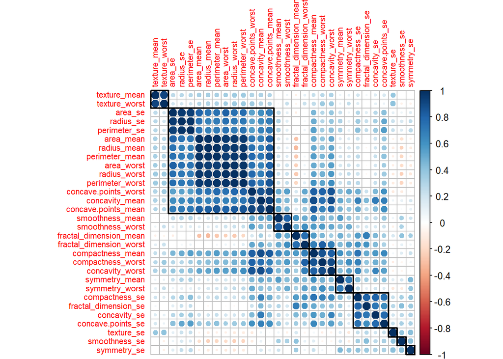

```r
library(ggplot2)

#remove diagnosis variable
df_corr = cor(subset(data, select = -c(diagnosis)))

corrplot::corrplot(df_corr, order = "hclust", tl.cex = 0.7, addrect = 10)
```

we can see that there are variables that are highly correlated.

On the next step, we will remove the highly correlated ones.

The findcorrelation() function from caret package remove highly correlated predictors. we’re going to remove variables based on whose correlation is above 0.9.

```r
library(caret)
data.clean = subset(data, select = -c(findCorrelation(df_corr, cutoff = 0.9)))
```

let’s check our new clean dataset

```r
# add back diagnosis


data.clean$diagnosis = data$diagnosis



str(data.clean)
```

```
## 'data.frame':    569 obs. of  22 variables:
##  $ perimeter_mean         : num  122.8 132.9 130 77.6 135.1 ...
##  $ area_mean              : num  1001 1326 1203 386 1297 ...
##  $ smoothness_mean        : num  0.1184 0.0847 0.1096 0.1425 0.1003 ...
##  $ concave.points_mean    : num  0.1471 0.0702 0.1279 0.1052 0.1043 ...
##  $ symmetry_mean          : num  0.242 0.181 0.207 0.26 0.181 ...
##  $ fractal_dimension_mean : num  0.0787 0.0567 0.06 0.0974 0.0588 ...
##  $ radius_se              : num  1.095 0.543 0.746 0.496 0.757 ...
##  $ area_se                : num  153.4 74.1 94 27.2 94.4 ...
##  $ smoothness_se          : num  0.0064 0.00522 0.00615 0.00911 0.01149 ...
##  $ compactness_se         : num  0.049 0.0131 0.0401 0.0746 0.0246 ...
##  $ concavity_se           : num  0.0537 0.0186 0.0383 0.0566 0.0569 ...
##  $ concave.points_se      : num  0.0159 0.0134 0.0206 0.0187 0.0188 ...
##  $ symmetry_se            : num  0.03 0.0139 0.0225 0.0596 0.0176 ...
##  $ radius_worst           : num  25.4 25 23.6 14.9 22.5 ...
##  $ area_worst             : num  2019 1956 1709 568 1575 ...
##  $ smoothness_worst       : num  0.162 0.124 0.144 0.21 0.137 ...
##  $ compactness_worst      : num  0.666 0.187 0.424 0.866 0.205 ...
##  $ concavity_worst        : num  0.712 0.242 0.45 0.687 0.4 ...
##  $ concave.points_worst   : num  0.265 0.186 0.243 0.258 0.163 ...
##  $ symmetry_worst         : num  0.46 0.275 0.361 0.664 0.236 ...
##  $ fractal_dimension_worst: num  0.1189 0.089 0.0876 0.173 0.0768 ...
##  $ diagnosis              : num  0 0 0 0 0 0 0 0 0 0 ...
```

our new data set is 9 columns shorter.

##### **scotter plot to overvue the data**

```r
library(reshape2)

#convert diagnosis into factor
data.clean$diagnosis= as.factor(data.clean$diagnosis)


df.m1 =data.clean
df.m = melt(df.m1)
```

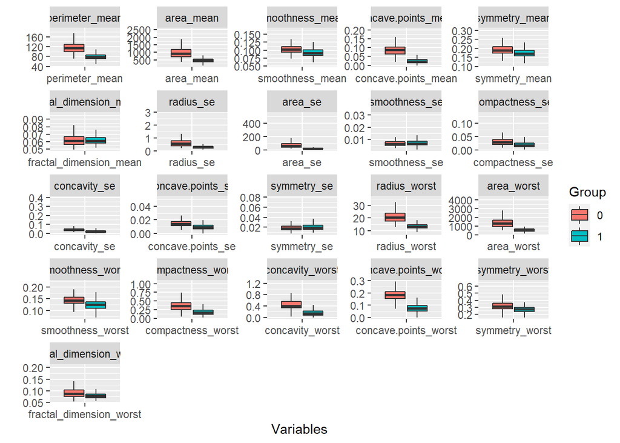

```r
p = ggplot(data = df.m, aes(x = variable, y = value)) +
   geom_boxplot(aes(fill=diagnosis), outlier.shape = NA) + facet_wrap(  ~ variable, scales="free")+ xlab("Variables") + ylab("")+ guides(fill=guide_legend(title="Group"))
p
```

plots above shows that, the malignant diagnoses have higher scores in almost variables.

#### **Correlations between outcome diagnosis and variables**

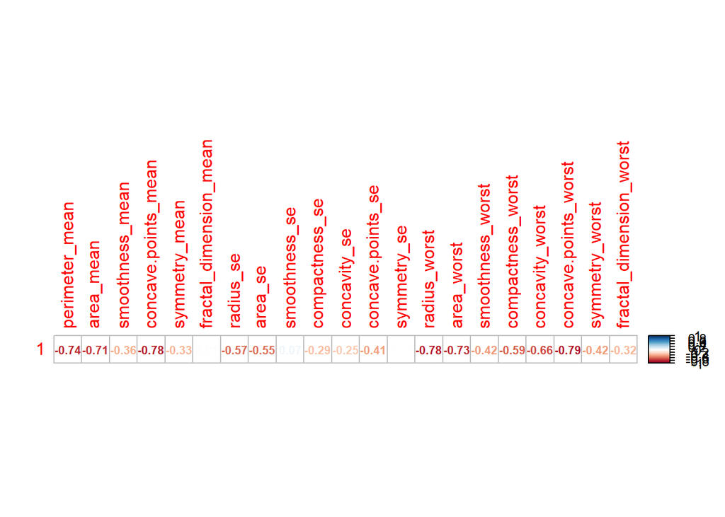

```r
library(corrplot)
#convert diagnosis into numeric
data.clean$diagnosis= as.numeric(data.clean$diagnosis)

dcor= cor(as.matrix(data.clean[,22]), as.matrix(data.clean[,-22]))


corrplot::corrplot(dcor, method = "number", number.cex = .7)
```

we’ve converted the categorical variable diagnosis to binary form beforehand, than using the R cor with the Pearson default command will work, and the correlation will be a point-biserial correlation.

from results above we can see that we can remove these variable from our dataset as they have very low correlation with variable diagnosis.

fractal_dimension_mean, smoothness_se, and symmetry_se.

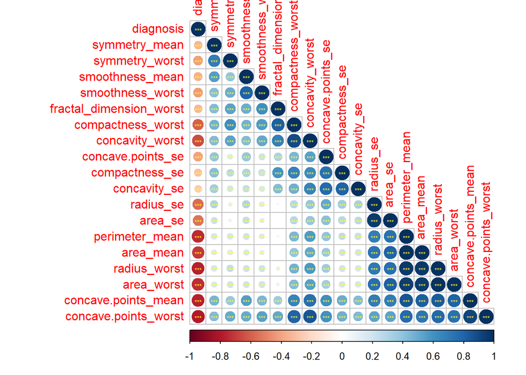

```r
data.clean= subset(data.clean, select = -c(fractal_dimension_mean))
data.clean= subset(data.clean, select = -c(smoothness_se))
data.clean= subset(data.clean, select = -c(symmetry_se))

data.clean$diagnosis= as.numeric(data.clean$diagnosis)

# calculating the correlation test with confidence level 0.95%
corr_p = cor.mtest(data.clean, conf.level = 0.95)

# calculating the correlation values
corr_val <- cor(data.clean)


# correlation graph
corrplot(corr_val,type = "lower",order="hclust", p.mat = corr_p$p, insig = "label_sig",
         sig.level = c(.001, .01, .05), pch.cex = .5, pch.col = "yellow")
```

now we can start building our model to predict whether the cancer is benign or malignant.

### **Model the data**

Let’s first create a testing and training set. Dataset is divided into two datasets: training (70%) and testing (30%).

```r
# converting diagnosis back to factor

data.clean$diagnosis= as.factor(data.clean$diagnosis)

head(data.clean)
```

```
##   perimeter_mean area_mean smoothness_mean concave.points_mean symmetry_mean
## 1         122.80    1001.0         0.11840             0.14710        0.2419
## 2         132.90    1326.0         0.08474             0.07017        0.1812
## 3         130.00    1203.0         0.10960             0.12790        0.2069
## 4          77.58     386.1         0.14250             0.10520        0.2597
## 5         135.10    1297.0         0.10030             0.10430        0.1809
## 6          82.57     477.1         0.12780             0.08089        0.2087
##   radius_se area_se compactness_se concavity_se concave.points_se radius_worst
## 1    1.0950  153.40        0.04904      0.05373           0.01587        25.38
## 2    0.5435   74.08        0.01308      0.01860           0.01340        24.99
## 3    0.7456   94.03        0.04006      0.03832           0.02058        23.57
## 4    0.4956   27.23        0.07458      0.05661           0.01867        14.91
## 5    0.7572   94.44        0.02461      0.05688           0.01885        22.54
## 6    0.3345   27.19        0.03345      0.03672           0.01137        15.47
##   area_worst smoothness_worst compactness_worst concavity_worst
## 1     2019.0           0.1622            0.6656          0.7119
## 2     1956.0           0.1238            0.1866          0.2416
## 3     1709.0           0.1444            0.4245          0.4504
## 4      567.7           0.2098            0.8663          0.6869
## 5     1575.0           0.1374            0.2050          0.4000
## 6      741.6           0.1791            0.5249          0.5355
##   concave.points_worst symmetry_worst fractal_dimension_worst diagnosis
## 1               0.2654         0.4601                 0.11890         1
## 2               0.1860         0.2750                 0.08902         1
## 3               0.2430         0.3613                 0.08758         1
## 4               0.2575         0.6638                 0.17300         1
## 5               0.1625         0.2364                 0.07678         1
## 6               0.1741         0.3985                 0.12440         1
```

```r
set.seed(1000)

smp_size = floor(0.70 * nrow(data.clean))
train_ind = sample(seq_len(nrow(data.clean)), size = smp_size)
train = data.clean[train_ind, ]
test = data.clean[-train_ind, ]
```

Let’s check how balanced is our response variable by frequency of cancer stages

```r
#train$diagnosis
prop.table(table(train$diagnosis))*100
```

```
##
##        1        2
## 37.43719 62.56281
```

```r
#"test$diagnosis"
prop.table(table(test$diagnosis))*100
```

```
##
##        1        2
## 36.84211 63.15789
```

#### **machine learning**

##### **Logistic regression**

i’m going to start with a logistic regression

training the model

```r
fitControl = trainControl(## 10-fold CV
  method = "cv",
  number = 10,
  savePredictions = TRUE)

lreg=train(diagnosis~.,data=train,method="glm",family=binomial(),
             trControl=fitControl)
```

testing the model

```r
lreg_pred<-predict(lreg,test[,-19])
cm_logistic<-confusionMatrix(lreg_pred,test$diagnosis)
cm_logistic
```

```
## Confusion Matrix and Statistics
##
##           Reference
## Prediction   1   2
##          1  58   3
##          2   5 105
##
##                Accuracy : 0.9532
##                  95% CI : (0.9099, 0.9796)
##     No Information Rate : 0.6316
##     P-Value [Acc > NIR] : <2e-16
##
##                   Kappa : 0.8988
##
##  Mcnemar's Test P-Value : 0.7237
##
##             Sensitivity : 0.9206
##             Specificity : 0.9722
##          Pos Pred Value : 0.9508
##          Neg Pred Value : 0.9545
##              Prevalence : 0.3684
##          Detection Rate : 0.3392
##    Detection Prevalence : 0.3567
##       Balanced Accuracy : 0.9464
##
##        'Positive' Class : 1
##
```

##### **k-nearest neighbor**

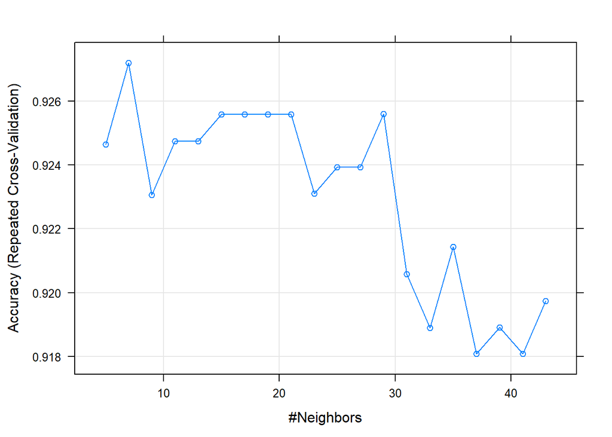

```r
control = trainControl(method='repeatedcv',
                        number=10,
                        repeats=3)
knnFit = train(diagnosis ~ ., data = train, method = "knn", trControl = control,tuneLength = 20)
plot(knnFit)
```

testing the model

```r
knnPredict = predict(knnFit,newdata = test[,-19] )
cm_knn=confusionMatrix(knnPredict, test$diagnosis )
cm_knn
```

```
## Confusion Matrix and Statistics
##
##           Reference
## Prediction   1   2
##          1  52   3
##          2  11 105
##
##                Accuracy : 0.9181
##                  95% CI : (0.8664, 0.9545)
##     No Information Rate : 0.6316
##     P-Value [Acc > NIR] : < 2e-16
##
##                   Kappa : 0.8193
##
##  Mcnemar's Test P-Value : 0.06137
##
##             Sensitivity : 0.8254
##             Specificity : 0.9722
##          Pos Pred Value : 0.9455
##          Neg Pred Value : 0.9052
##              Prevalence : 0.3684
##          Detection Rate : 0.3041
##    Detection Prevalence : 0.3216
##       Balanced Accuracy : 0.8988
##
##        'Positive' Class : 1
##
```

##### **Support vector machines**

Training the model.

```r
library(e1071)

learn_svm = svm(diagnosis~., data=train)
```

Testing the model.

```r
pre_svm = predict(learn_svm, test[,-19])
cm_svm = confusionMatrix(pre_svm, test$diagnosis)
cm_svm
```

```
## Confusion Matrix and Statistics
##
##           Reference
## Prediction   1   2
##          1  56   0
##          2   7 108
##
##                Accuracy : 0.9591
##                  95% CI : (0.9175, 0.9834)
##     No Information Rate : 0.6316
##     P-Value [Acc > NIR] : < 2e-16
##
##                   Kappa : 0.91
##
##  Mcnemar's Test P-Value : 0.02334
##
##             Sensitivity : 0.8889
##             Specificity : 1.0000
##          Pos Pred Value : 1.0000
##          Neg Pred Value : 0.9391
##              Prevalence : 0.3684
##          Detection Rate : 0.3275
##    Detection Prevalence : 0.3275
##       Balanced Accuracy : 0.9444
##
##        'Positive' Class : 1
##
```

#### **determining the best model**

i have deployed several classification Machine algorithm using the predictor defined before.

- Logistic regression: had an Accuracy of 0.9532,
- k-nearest neighbor: had an Accuracy of 0.9181,
- Support vector machines: 0.9591,

based on these finding support vector machine seems to have highest accuracy score.

#### **References:**

This data set is available through Kaggle : https://www.kaggle.com/uciml/breast-cancer-wisconsin-data

and is also available through the UW CS ftp server: ftp ftp.cs.wisc.edu cd math-prog/cpo-dataset/machine-learn/WDBC/

Breast Cancer Prediction in R retrived from : https://setscholars.net/wp-content/uploads/2019/11/Breast-Cancer-Prediction-in-R.html

Wisconsin Breast Cancer Analysis with k-Nearest Neighbors (k-NN) Algorithm in R retrived from: https://www.engineeringbigdata.com/wisconsin-breast-cancer-analysis-with-k-nearest-neighbors-k-nn-algorithm-in-r/

Basic Machine Learning with Cancer retrived from : https://www.kaggle.com/gargmanish/basic-machine-learning-with-cancer

Discovering Statistics Using R, Andy Field | Jeremy Miles | Zoe Field R For Everyone, Jared P Lander